# Faunalytics R Tables and Figures Style Guide

2024-10-25

# Requirements

## Install CRAN packages

Make sure you have installed both the `tidyverse` (which contains ggplot2, dplyr, and many other common packages) and the `gt` package (tables). You will also need the `devtools` package.

```r
install.packages("tidyverse")
install.packages("gt")
install.packages("devtools")
```

## Install the `faunalytics` package

Always be sure to install the most recent version of the `faunalytics` package:

```r
devtools::install_github("faunalytics/faunalytics")
```

Contact Zach if you run into any issues with installation or with the `faunalytics` package.

## Install and load the Gotham font family

If you have not already, make sure to download and install all of [the Gotham fonts](https://drive.google.com/file/d/1ZgXfzdITIsMVlqZKRcLKiERzznSxfhDq/view?usp=sharing).

Once installed, they can be loaded in R using the extrafont package.

```r
install.packages("extrafont") # install extrafont package
extrafont::font_import(pattern = "Gotham") # load Gotham fonts
extrafont::loadfonts(device = "win") # only needed if you're on a Windows computer
```

If you run into issues getting the fonts to work, there are a lot of troubleshooting resources online. You could try the `showtext` page as an alternative to `extrafont.` You can also contact Zach for support.

## Webshot

We use the `gt` package for tables. In order to save `gt` objects to PNGs like we want to, we’ll need to install the `webshot` package and use it to install PhantomJS. Like all R installations, you’ll only need to do this once.

```r
install.packages("webshot")
webshot::install_phantomjs()
```

# Overview

*An important note:* You should default to the styles and standards outlined in this document. However, there may be cases when it makes more sense to deviate from these guidelines for the sake of clarity and/or readability.

As communicators of scientific information, it is important that our work is clear and consistent. This is true for both our writing and our visuals. To that end, there are certain styles and standards we should use to make sure that we have a consistent aesthetic across reports.

The `faunalytics` package comes with several functions designed to make it easy to follow these standards. These include `theme_faunalytics` for `ggplot` objects and `table_format` for `gt` tables, both of which are discussed below. Other helpful functions include `fauna_colors` and `fauna_blues`, also discussed below.

## Colors

The standard Faunalytics color palette includes green, amber, red, and blue, which can be broken down into dark blue, light blue, and regular blue. Rather than the standard shades of these colors (e.g., #FF0000 for red), we use specific brand shades (e.g., #E64B3D for red). The specific shades we use can be accessed using the `fauna_colors` function.

```r
# return hex code for red
fauna_colors("red")
```

```
## [1] "#E64B3D"
```

```r
# return all hex codes in standard palette
fauna_colors()
```

```
## [1] "#73A753" "#FF8F2D" "#E64B3D" "#254C59" "#5FB7E5" "#0092B2"
```

```r
# return all hex codes in standard palette with names for clarity
fauna_colors(nameless = FALSE)
```

```
##     green     amber       red  darkblue lightblue      blue
## "#73A753" "#FF8F2D" "#E64B3D" "#254C59" "#5FB7E5" "#0092B2"
```

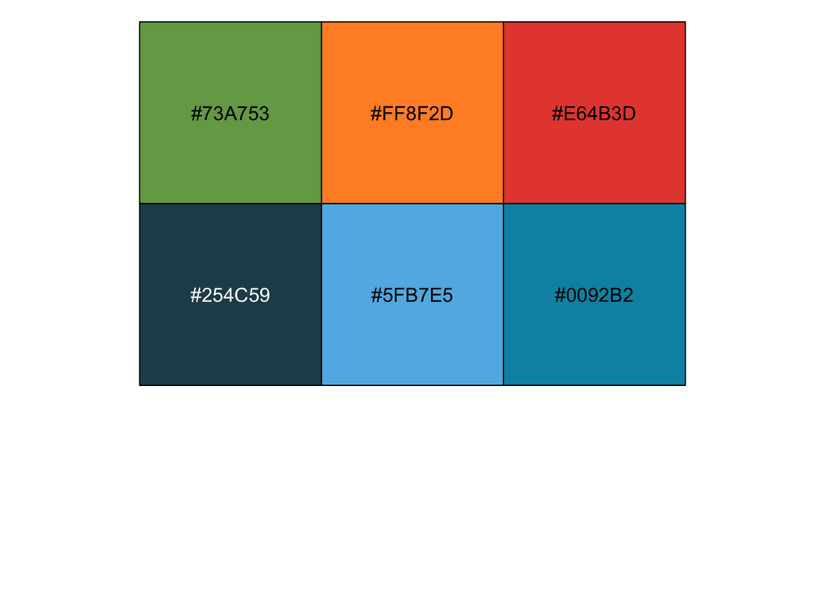

Unfortunately, some of these colors don’t work well together (e.g., green and red aren’t colorblind-friendly). Green is also often associated with “good” and red with “bad.” To avoid issues and limitations such as these, graphics should generally default to shades of blue.

When using only one color, use dark blue (#254C59) . When using two colors, use dark blue and light blue (#5FB7E5). When using three colors, use dark blue, regular blue (#0092B2), and light blue. If appropriate, use additional shades of blue when using more than three colors. You can access all of these shades of blue by providing the number of shades you need to the `fauna_blues` function. When the number you provide is greater than three, the function interpolates shades between dark blue and light blue.

```r
fauna_blues(1) # dark blue only
```

```
## [1] "#254C59"
```

```r
fauna_blues(2) # dark blue and light blue
```

```
## [1] "#254C59" "#5FB7E5"
```

```r
fauna_blues(3) # dark blue, regular blue, and light blue
```

```
## [1] "#254C59" "#0092B2" "#5FB7E5"
```

```r
fauna_blues(6) # dark blue, four interpolated shades, and light blue
```

```
## [1] "#254C59" "#306175" "#3C7691" "#478CAD" "#53A1C9" "#5FB7E5"
```

# ggplot

We typically use the `ggplot2` package for graphs. At the end of your ggplot chunk, you can add `+ theme_faunalytics()` to standardize many aspects of your plot’s theme. For example, notice the difference between these two plots below.

We’ll summarize the mtcars data for the examples below.

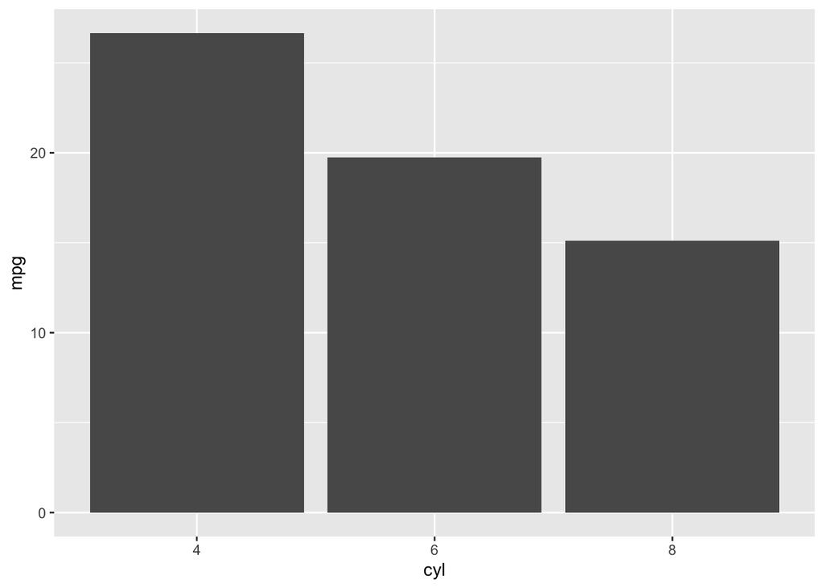

```r
ggplot(mtcars2, aes(x = cyl, y = mpg)) +
  geom_col() # without the Faunalytics theme
```

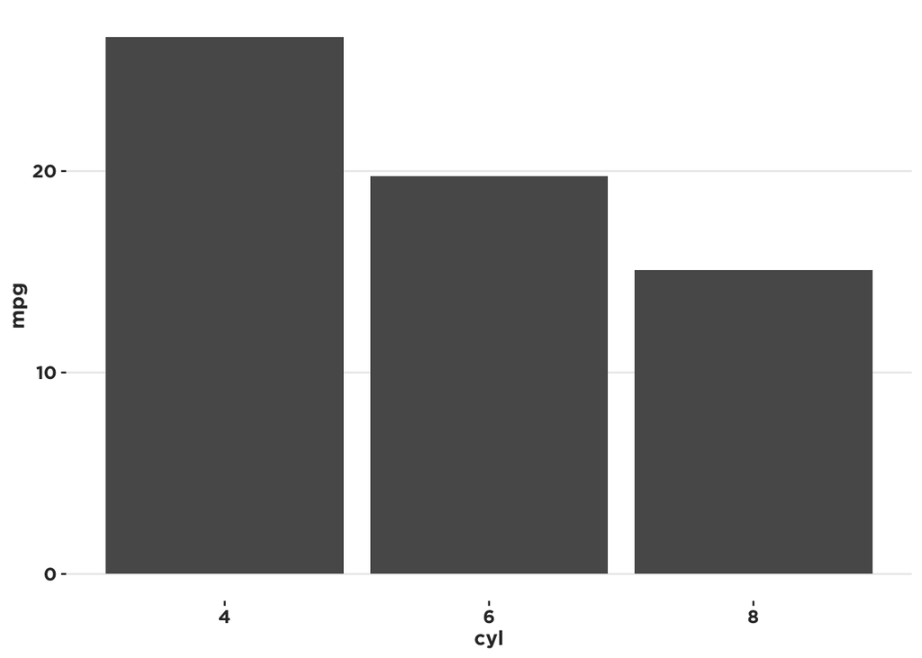

```r
ggplot(mtcars2, aes(x = cyl, y = mpg)) +
  geom_col() +
  theme_faunalytics() # with the Faunalytics theme
```

*Note:* In `ggplot`, if you’re referring to a variable in your dataset, it should be referenced within the `aes()` command, like `aes(x = cyl, y = mpg)`. However, if you’re referencing something that’s *not* in your data, it should be referenced outside of the `aes()` command, like `fill = fauna_colors("darkblue")`.

Where white would be used, we just stick with the standard white (#FFFFFF). You can also access this by using `fauna_colors("white")`. However, rather than black, we use a slightly softer dark gray (#333333), accessed using `fauna_colors("darkgray")`.

You may notice that the graph is not entirely in the Faunalytics colors scheme. Unfortunately, this can’t be automatically applied using `theme_faunalytics` and requires specification. For example:

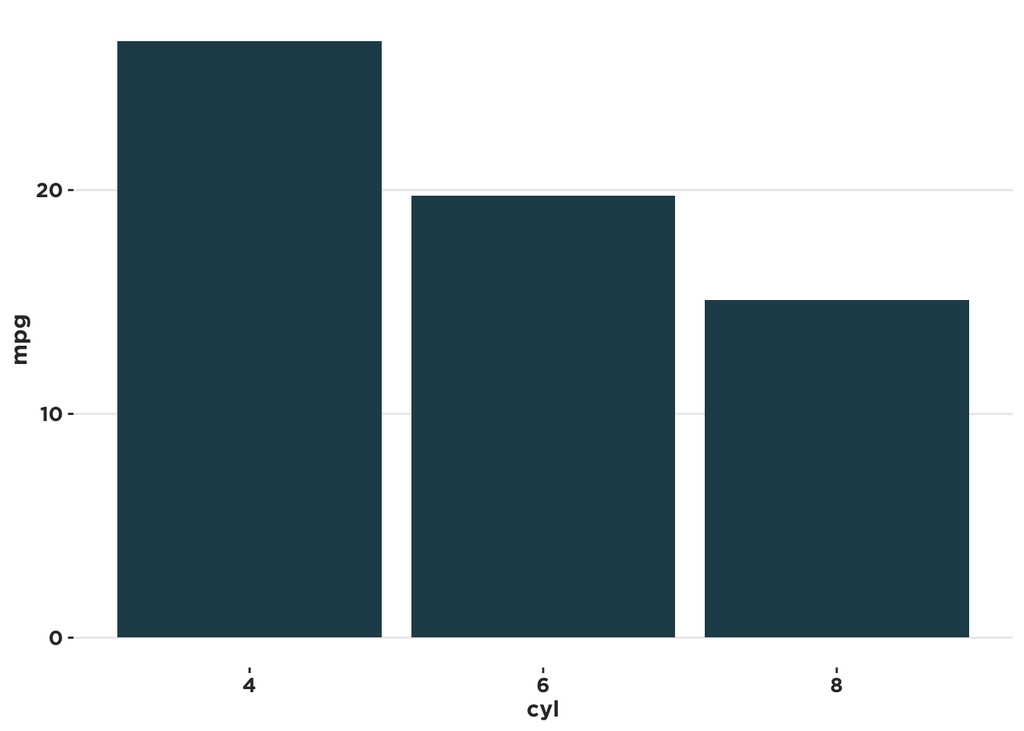

```r
ggplot(mtcars2, aes(x = cyl, y = mpg)) +
  geom_col(fill = fauna_blues(1)) + # make all columns the same color
  theme_faunalytics()
```

or

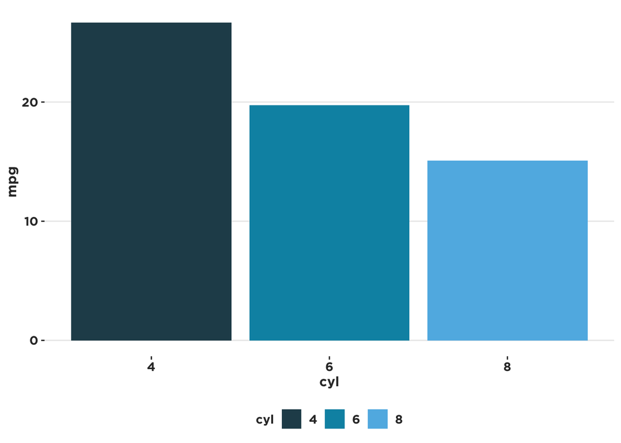

```r
ggplot(mtcars2, aes(x = cyl, y = mpg)) +
  geom_col(aes(fill = cyl)) + # change color based on cyl value
  scale_fill_manual(values = fauna_blues(3)) +
  theme_faunalytics()
```

*Note:* In ggplot terms, `fill` is the term for bars and other things that are *filled in* with a color. `color` refers to lines, points, and borders.

You can use a function like `scale_fill_manual` or `scale_color_manual` to tell `ggplot` to use specific, discrete colors. If you need a gradient, you can use functions like `scale_fill_gradient` or `scale_color_gradient`. For example, you can have a gradient go from dark blue to light blue using:

```r
... +
scale_fill_gradient(low = fauna_colors("darkblue"),
                    high = fauna_colors("lightblue")) +
...
```

## Maximizing the data-ink ratio

In general, we want to try to adhere to statistician and data viz legend [Edward Tufte’s principles for graphing](https://thedoublethink.com/tuftes-principles-for-visualizing-quantitative-information/), which emphasize showing the data and reducing the amount of unnecessary components on a graphic (aka maximizing the data-ink ratio). To this end, we often want to remove things like axis titles, axis text, axis ticks, etc. if they aren’t providing critical information that isn’t available somewhere else. Take the following graph as an example. The graph title appears before the code because we type this titles into reports rather than embedding them in the graph images.

#### Average miles per gallon by number of engine cylinders

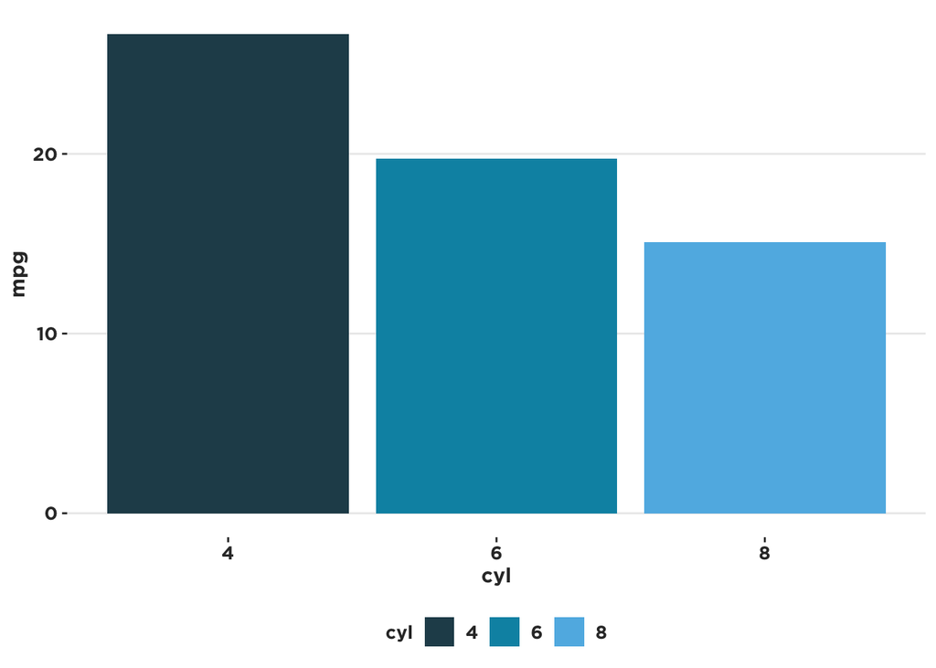

```r
ggplot(mtcars2, aes(x = cyl, y = mpg)) +
  geom_col(aes(fill = cyl)) +
  scale_fill_manual(values = fauna_blues(3)) +
  theme_faunalytics()
```

The y axis title and x axis title are made redundant by the graph title. The x axis text could also be eliminated if we more clearly label the legend. Since we won’t need the x axis text, we can also eliminated the associated ticks. We can get rid of this redundant information using a `theme()` command, plus an additional tweak to rename the legend.

#### Average miles per gallon by number of engine cylinders

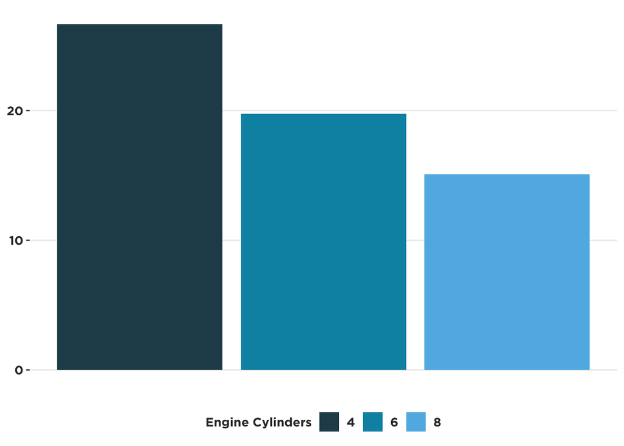

```r
ggplot(mtcars2, aes(x = cyl, y = mpg)) +
  geom_col(aes(fill = cyl)) +
  scale_fill_manual("Engine Cylinders", # rename legend
                    values = fauna_blues(3)) +
  theme_faunalytics() +
  theme(axis.title = element_blank(), # hide axis titles
        axis.text.x = element_blank(), # hide x axis text (i.e., 4, 6, 8)
        axis.ticks.x = element_blank()) # hide x axis ticks
```

*Note:* The `theme` command must go *after* the `theme_faunalytics` command.

You can get rid of elements by setting them equal to element_blank() as done in the above example. For additional ways to change the defaults, see [this ggplot2 guide](https://ggplot2.tidyverse.org/reference/theme.html).

While we’re at it, we can make a few more tweaks to make the graphic better.

#### Average miles per gallon by number of engine cylinders

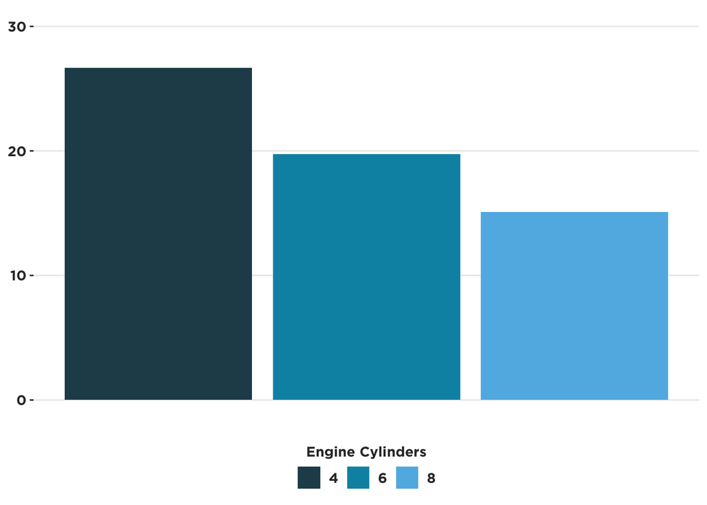

```r
ggplot(mtcars2, aes(x = cyl, y = mpg)) +
  geom_col(aes(fill = cyl)) +
  scale_fill_manual("Engine Cylinders",
                    values = fauna_blues(3)) +
  scale_y_continuous(limits = c(0, 30), # set y axis limits
                    breaks = seq(0, 30, 10)) + # set y tick locations (0 to 30 every 10 units))
  guides(fill = guide_legend(title.position = "top")) + # put legend title above legend
  theme_faunalytics() +
  theme(axis.title = element_blank(),
        axis.text.x = element_blank(),
        axis.ticks.x = element_blank())
```

## Data labels

We can also add data labels. This may seem like it contradicts the data-ink ratio maximization guideline, but it doesn’t really because we’re using these data labels to provide additional information. Rather than guessing what the heights of the bars are, we’re providing additional information.

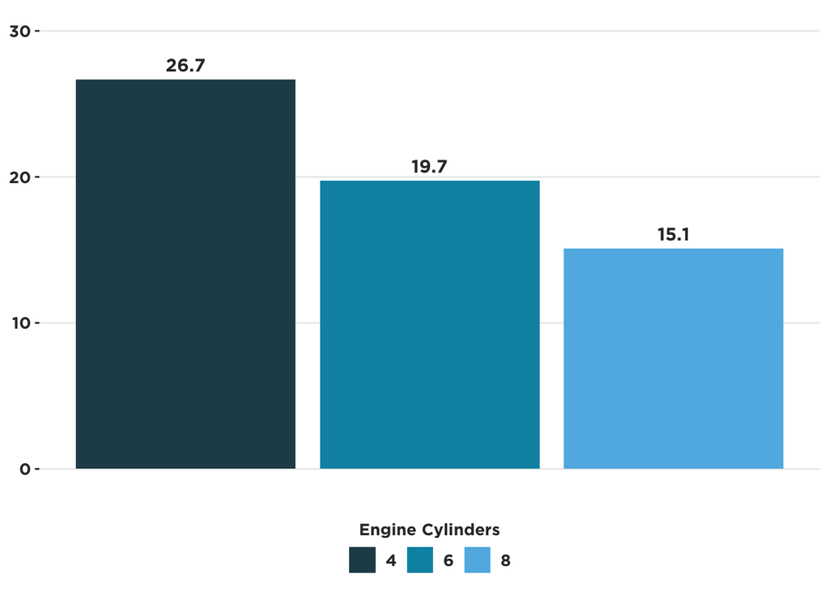

```r
ggplot(mtcars2, aes(x = cyl, y = mpg)) +
  geom_col(aes(fill = cyl)) +
  geom_text(aes(label = sprintf("%.1f", mpg), # label with mpg, rounded to 1 decimal place
                y = mpg + 1), # place label one unit above top of bar
            color = fauna_colors("darkgray"), # set text to dark gray
            family = "Gotham Bold") + # change font to Gotham Bold
  scale_fill_manual("Engine Cylinders",
                    values = fauna_blues(3)) +
  scale_y_continuous(limits = c(0, 30),
                    breaks = seq(0, 30, 10)) +
  guides(fill = guide_legend(title.position = "top")) +
  theme_faunalytics() +
  theme(axis.title = element_blank(),
        axis.text.x = element_blank(),
        axis.ticks.x = element_blank())
```

Above, we change the font to Gotham Bold. This is our standard **bold** font. For non-bold fonts, we use Gotham Book. We also changed the default text color (black) to dark gray and moved the label up a bit so it wouldn’t overlap the bar. These are all adjustments to how our `label` shows up. We could have simply set this to `mpg`, but it would have given a lot of decimal places. Since we only want one decimal place, we wrap it in the `sprintf` function. “%.1f” gives us one decimal place (.1 for one decimal place, .2 for two decimal places, etc.). We could have use `round(mpg, 1)` instead, but this would not have displayed a 0 in the decimal place if any existed.

## Other things

### Error bars

We set the color of error bars to gray (#808080) so they show up clearly. You can do this using `fauna_colors("gray")`. We also set the default width of error bars to .15.

## Grouped bars, labels, and error bars

If you want to make a grouped bar plot, you have to tell `ggplot` that by setting the fill to a variable. This will create a *stacked* bar plot. To make it a grouped bar plot, you have to tell `ggplot` to unstack it. To do this, we add the argument `position = position_dodge()` to the `geom_*` line. By default, the width (distance of the grouped bars) is .9. If you have labels on the bars or error bars, you’ll also need to set those to be position dodged and you’ll need to manually set the width to .9: `position = position_dodge(width = .9)`. You can see an example of all of this below using a different summarized version of the `mtcars` dataset.

#### Average miles per gallon by number of engine cylinders and transmission type

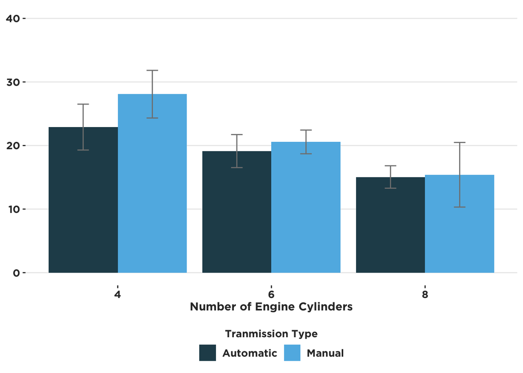

```r
ggplot(mtcars3, aes(x = cyl, y = mpg,
                    fill = am)) + # move fill to ggplot line so it applies to everything below
  geom_col(position = position_dodge()) + # set position_dodge for bars (columns)
  geom_errorbar(aes(ymin = lower_ci, # set error bar minimum to pre-calculated value
                    ymax = upper_ci), # # set error bar maximum to pre-calculated value
                color = fauna_colors("gray"), # set error bar color to gray
                width = .15, # set error bar width
                position = position_dodge(width = .9)) + # specify dodged position and width
  scale_fill_manual("Tranmission Type",
                    values = fauna_blues(2)) +
  scale_y_continuous(limits = c(0, 40),
                    breaks = seq(0, 40, 10)) +
  labs(x = "Number of Engine Cylinders") +
  guides(fill = guide_legend(title.position = "top")) +
  theme_faunalytics() +
  theme(axis.title.y = element_blank()) # hide only y axis title
```

### Axis scaling

Axes should also be appropriately scaled. For example, if we’re showing percentages and a 0%-100% axis, the axis shouldn’t show up as 0.0 to 1.0, it should show up as 0% to 100%. (Data labels should match this as well.)

The `scales` package allows us to make these changes fairly easily. Take the following graph as an example:

#### Percentage of cars in `mtcars` data by number of cylinders

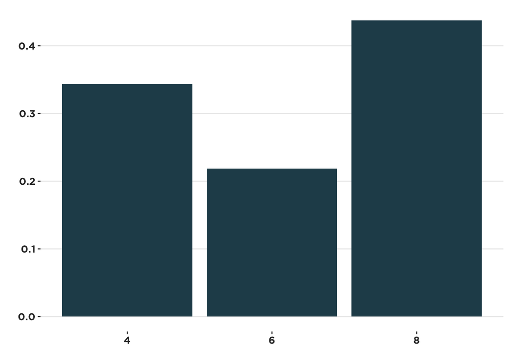

```r
mtcars |>
 tabyl(cyl) |>
  ggplot(aes(x = as.factor(cyl), y = percent)) +
  geom_col(fill = fauna_colors("darkblue")) +
  labs(x = "", y = "") + # Set axis titles to blank
  theme_faunalytics()
```

We’re reporting percentages, so the y axis should reflect that more clearly. We can set the `labels` argument of the `scale_y_continous` (because we want to adjust the y axis of a continuous value, as opposed to `scale_y_discrete`) equal to `scales::percent` to tell ggplot to treat the y axis values as percentages.  
(The double colon is how you access a single function from an unloaded package: `package::function`. If we had run `library(scales)` earlier, we could have just written `percent`.)

#### Percentage of cars in `mtcars` data by number of cylinders

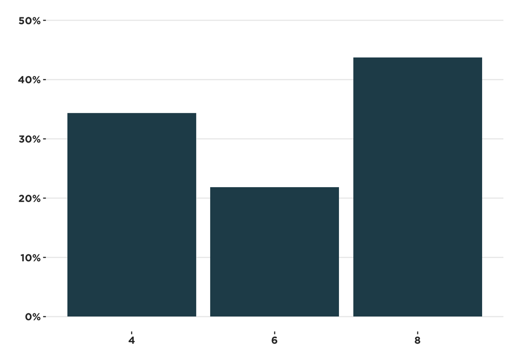

```r
mtcars |>
 tabyl(cyl) |>
  ggplot(aes(x = as.factor(cyl), y = percent)) +
  geom_col(fill = fauna_colors("darkblue")) +
  scale_y_continuous(limits = c(0, .5), # set minimum and maximum of axis
                     labels = scales::percent) + # show axis labels as percentages
  labs(x = "", y = "") +
  theme_faunalytics()
```

Similarly, we should format scales in the thousands and larger with commas. Again, we can use the `scales` package with the `scale_y_continuous` function.

#### Car weight by miles per gallon

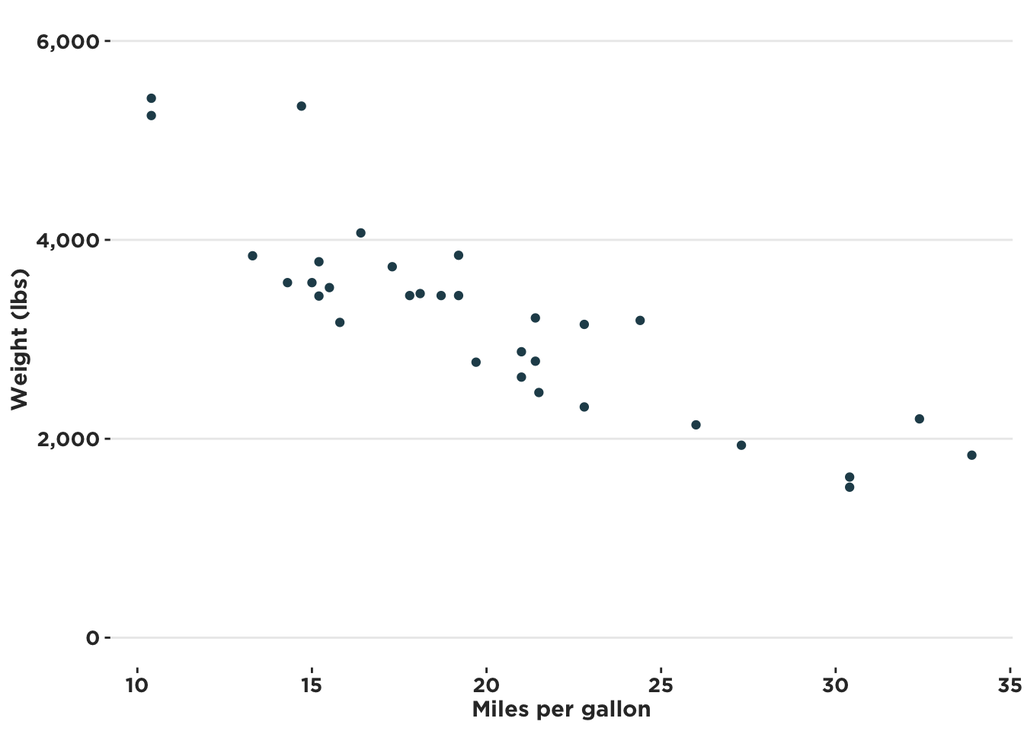

```r
mtcars |>
 mutate(wt = wt * 1000) |> # convert wt from showing thousands of lbs to showing lbs
  ggplot(aes(x = mpg, y = wt)) +
  geom_point(color = fauna_colors("darkblue")) + # geom_point uses color, not fill
  scale_y_continuous(limits = c(0, 6000), # set axis min and max
                     labels = scales::comma) + # use commas in axis text
  labs(x = "Miles per gallon", y = "Weight (lbs)") +
  theme_faunalytics()
```

The `scales` package comes with lots of ways to format axes, so it’s worth exploring it if you have/want to tweak axis labels.

## Saving

You can save images with the `ggsave` function. It safest to save your graph as an object using the `<-` operator and then call that plot by name (versus the alternative of relying on `ggsave`’s default “last plot” behavior).

`ggsave` requires you to specify a filename you’d like to save your plot as. You can include a full file path here and save the image as a png. Width and height are up to you, but changing these can sometimes affect how the plot renders, so be sure to check your saved image to make sure it looks correct.

An example of the ggsave syntax for a non-existent plot called `p_label_belief`:

```r
ggsave(filename = "output/figures/welfare-label-beliefs.png",
       plot = p_label_belief)
```

# Tables

Tables are annoying unfortunately. We incorporate a package called `gt` to make consistent, save-able tables. You can apply the default formatting using the function `table_format` from the `faunalytics` package. This function takes a dataframe and makes it a `gt` table. It will automatically name the columns whatever they’re name in your dataframe, so you may wish to rename them before using the `table_format` function.

Before showing this, let’s make some data to work with.

```r
mtcars_auto_tbl <- mtcars |>
  filter(am == 0) |> # subset data to keep only automatic transmission cars
  rownames_to_column("car") |> # turn rownames into a column called "car'
  mutate(make = trimws(str_extract(car, "^.*?\\s|^Valiant$"))) |> # extract car make
  tabyl(make) # create summary table
```

```r
mtcars_auto_tbl |>
  table_format()
```

| make | n | percent |
| --- | --- | --- |
| AMC | 1 | 0.0526315789473684 |
| Cadillac | 1 | 0.0526315789473684 |
| Camaro | 1 | 0.0526315789473684 |
| Chrysler | 1 | 0.0526315789473684 |
| Dodge | 1 | 0.0526315789473684 |
| Duster | 1 | 0.0526315789473684 |
| Hornet | 2 | 0.105263157894737 |
| Lincoln | 1 | 0.0526315789473684 |
| Merc | 7 | 0.368421052631579 |
| Pontiac | 1 | 0.0526315789473684 |
| Toyota | 1 | 0.0526315789473684 |
| Valiant | 1 | 0.0526315789473684 |

By default, any table with four or more rows gets alternate row shading to make the tables easier to read. This and many other features are changeable. See `?table_format` for more on that.

Unfortunately, many features have to be changed using `gt`’s clunky syntax. For anything not covered here, have a look at [this guide to gt](https://gt.rstudio.com/articles/gt.html).

## Alignment and column width

We’ll need to change the names of the columns, but let’s save that for last so that we don’t have to deal with capitalization and so on.

Unlike with `ggplot`, it’s tricky to reformat columns in `gt`, so we’ll reformat our percentages and numbers before applying the `table_format` function.

```r
mtcars_auto_tbl |>
  mutate(percent = paste0(round(100 * percent, 0), "%"), # reformat percentage
         n = format(n, big.mark = ",")) |> # add comma separators
  table_format()
```

| make | n | percent |
| --- | --- | --- |
| AMC | 1 | 5% |
| Cadillac | 1 | 5% |
| Camaro | 1 | 5% |
| Chrysler | 1 | 5% |
| Dodge | 1 | 5% |
| Duster | 1 | 5% |
| Hornet | 2 | 11% |
| Lincoln | 1 | 5% |
| Merc | 7 | 37% |
| Pontiac | 1 | 5% |
| Toyota | 1 | 5% |
| Valiant | 1 | 5% |

The line adding comma separators isn’t necessary because our numbers are all below 1,000, but I’ve included it because it could be helpful in other cases.

We might get the proper alignment for our columns, but just in case we didn’t or we want to be extra safe, we can specify column alignment like this:

```r
mtcars_auto_tbl |>
  mutate(percent = paste0(round(100 * percent, 0), "%"),
         n = format(n, big.mark = ",")) |>
  table_format() |>
  cols_align(align = "right", # specify alignment direction
             columns = c(n, percent)) # name columns in vector (using c())
```

| make | n | percent |
| --- | --- | --- |
| AMC | 1 | 5% |
| Cadillac | 1 | 5% |
| Camaro | 1 | 5% |
| Chrysler | 1 | 5% |
| Dodge | 1 | 5% |
| Duster | 1 | 5% |
| Hornet | 2 | 11% |
| Lincoln | 1 | 5% |
| Merc | 7 | 37% |
| Pontiac | 1 | 5% |
| Toyota | 1 | 5% |
| Valiant | 1 | 5% |

We can specify column width as well. You can do this with either pixels (`px`) or with percentages (`pct`). `px` is probably the better option in most cases. As a note, the `cols_width` functionworks with tidyverse shortcut functions like `contains` or `starts_with`.

```r
mtcars_auto_tbl |>
  mutate(percent = paste0(round(100 * percent, 0), "%"),
         n = format(n, big.mark = ",")) |>
  table_format() |>
  cols_align(align = "right",
             columns = c(n, percent)) |>
  cols_width(make ~ px(100), # specify width in pixels
             n ~ px(110), # bigger than needed here so we can rename it
             percent ~ px(110))
```

| make | n | percent |
| --- | --- | --- |
| AMC | 1 | 5% |
| Cadillac | 1 | 5% |
| Camaro | 1 | 5% |
| Chrysler | 1 | 5% |
| Dodge | 1 | 5% |
| Duster | 1 | 5% |
| Hornet | 2 | 11% |
| Lincoln | 1 | 5% |
| Merc | 7 | 37% |
| Pontiac | 1 | 5% |
| Toyota | 1 | 5% |
| Valiant | 1 | 5% |

We can also format specific rows or columns. For example, let’s say we wanted a “Total” row at the bottom of this table. We’d want to make a border line and to bold the text. This is where things get extra clunky. You’ll need to use `gt`’s tab_style function. See the guide linked above or `?gt::tab_style` for more info on how to use this.

```r
mtcars_auto_tbl |>
  adorn_totals() |> # add totals row to tabyl object
  mutate(percent = paste0(round(100 * percent, 0), "%"),
         n = format(n, big.mark = ",")) |>
  table_format() |>
  cols_align(align = "right",
             columns = c(n, percent)) |>
  cols_width(make ~ px(100),
             n ~ px(110),
             percent ~ px(110)) |>
    tab_style( # format specific cells
    style = list(
      cell_text(weight = "bold"), # make text bold
      cell_borders(sides = c("top"), # add border to top of specific cells
                   color = fauna_colors("darkgrey"), # make border dark gray
                   weight = px(2)) # make border 2px thick
    ),
    locations = cells_body(
      rows = percent == "100%" # apply the above style to rows where the
      # value of the percent column is equal to "100%"
    ))
```

| make | n | percent |
| --- | --- | --- |
| AMC | 1 | 5% |
| Cadillac | 1 | 5% |
| Camaro | 1 | 5% |
| Chrysler | 1 | 5% |
| Dodge | 1 | 5% |
| Duster | 1 | 5% |
| Hornet | 2 | 11% |
| Lincoln | 1 | 5% |
| Merc | 7 | 37% |
| Pontiac | 1 | 5% |
| Toyota | 1 | 5% |
| Valiant | 1 | 5% |
| Total | 19 | 100% |

Now we can rename the columns to finalize the table.

```r
mtcars_auto_tbl |>
  adorn_totals() |>
  mutate(percent = paste0(round(100 * percent, 0), "%"),
         n = format(n, big.mark = ",")) |>
  table_format() |>
  cols_align(align = "right",
             columns = c(n, percent)) |>
  cols_width(make ~ px(100),
             n ~ px(110),
             percent ~ px(110)) |>
    tab_style(
    style = list(
      cell_text(weight = "bold"),
      cell_borders(sides = c("top"),
                   color = fauna_colors("darkgrey"),
                   weight = px(2))
    ),
    locations = cells_body(
      rows = percent == "100%"
    )) |>
    cols_label(make = "Car Make",
               n = "Frequency",
               percent = "Percentage")
```

| Car Make | Frequency | Percentage |
| --- | --- | --- |
| AMC | 1 | 5% |
| Cadillac | 1 | 5% |
| Camaro | 1 | 5% |
| Chrysler | 1 | 5% |
| Dodge | 1 | 5% |
| Duster | 1 | 5% |
| Hornet | 2 | 11% |
| Lincoln | 1 | 5% |
| Merc | 7 | 37% |
| Pontiac | 1 | 5% |
| Toyota | 1 | 5% |
| Valiant | 1 | 5% |
| Total | 19 | 100% |

```r
mtcars_auto_tbl |>
  adorn_totals() |>
  mutate(percent = paste0(round(100 * percent, 0), "%"),
         n = format(n, big.mark = ",")) |>
  table_format() |>
  cols_align(align = "right",
             columns = c(n, percent)) |>
  cols_width(make ~ px(100),
             n ~ px(110),
             percent ~ px(110)) |>
    tab_style(
    style = list(
      cell_text(weight = "bold"),
      cell_borders(sides = c("top"),
                   color = fauna_colors("darkgrey"),
                   weight = px(2))
    ),
    locations = cells_body(
      rows = percent == "100%"
    )) |>
    cols_label(make = md("Car<br/>Make"), # add line break and markdown specification
               n = "Frequency",
               percent = "Percentage")
```

| Car Make | Frequency | Percentage |
| --- | --- | --- |
| AMC | 1 | 5% |
| Cadillac | 1 | 5% |
| Camaro | 1 | 5% |
| Chrysler | 1 | 5% |
| Dodge | 1 | 5% |
| Duster | 1 | 5% |
| Hornet | 2 | 11% |
| Lincoln | 1 | 5% |
| Merc | 7 | 37% |
| Pontiac | 1 | 5% |
| Toyota | 1 | 5% |
| Valiant | 1 | 5% |
| Total | 19 | 100% |

To save this, we’d store it as an object using `<-` and run the appropriate save function, just like with a `ggplot` graph. In this case, we’d use `gtsave`. On a non-existent object called `gt_tbl`, we’d save that like this:

```r
gtsave(gt_tbl, "output/tables/table-1-results.png") # save table as png
```

[figure not shown]